# Classification Models For Predicting NBA Team Over Unders

Tony

June 1, 2017

# Introduction

## Purpose

This project involves my experimentation with various classification models for predicting whether or not an NBA team will go over or under the number of wins projected by sportsbooks. As those who are familiar with the NBA and sports betting may already know, correctly identifying the outcome of a team’s season relative to the sportsbook’s win total projection is a highly random task. To explain, the difficult in making predictions is due to a number of factors, including the unpredictability of roster composition as a result of in-season injuries to key players, roster changes, player cohesion, etc.

## Goals

The best (professional) sports bettors might only correctly predict 18 (or 60%) of outcomes in a given season on a consistent basis (if they were to bet on all team outcomes), and public (less experienced) bettors are more than likely to hover around 50% in aggreggate. Hence, if I can successfully create a statistical model that can correctly predict outcomes consistently around 60%, I would consider that impressive. Additionally, I would prefer that the model is interpretable. (Consequently, models using techniques such as support vecotr machines (SVMs) might not be the best choice, but I’ll look at them, nonetheless).

## Inspiration

The inspiration for this project is multi-faceted:

- My brother and I record our picks for the over/unders for each team win total at the beginning of each NBA (and NFL) season and have wondered how well we might do if we actaully gambled. [^1]
- I wanted a project to help me develop my R skills.
- I wanted to practice some of the statistical and machine learning techniques that I have studied.

Although we have only been recording my over/under picks since 2012, I will be looking at NBA seasons from 2007 to 2016 because I have sportsbook win total data going back to the 2007 season. [^2]

In this portion of the project, I’ll evaulate different models while trying to be as consistent as possible in my choice of predictors and my implementation of training, testing and validating data sets. Nevertheless, due to the nature of each model, it can be difficult to be completely consistent.

I only do some experimentation with choice of predictors and model formulations in this portion of the project; I’ll leave more extensive analysis of model specifications for another time. My primary intent here is to implement different model families used for classification. Nevertheless, I’ll use my best judgement and intuition in my selection of model parameters. [^3]

# Importing the Data

I start by loading in the data set for stats and team win totals. I have saved this data in local rds files for use across multiple projects. [^4]

```r
dir_data <- paste0(getwd(), "/data/")
d_win_totals_raw <-
  readRDS(paste0(dir_data, "d_win_totals.rds"))
names(d_win_totals_raw)
```

```
## [1] "record_id"    "pick_id"      "yr_start"     "team"
## [5] "w_sportsbook" "odds_over"    "odds_under"   "w"
```

```r
d_scraped_stats_classification_raw <-
  readRDS(paste0(dir_data, "d_scraped_stats_classification_raw.rds"))
names(d_scraped_stats_classification_raw)
```

```
## [1] "team"                           "yr_start"
## [3] "avg_scoring_margin"             "avg_margin_thru_three_quarters"
## [5] "win_pct_close_games"
```

The values in the imported data sets should be fairly self-explanatory given the column names. Perhaps the only ambiguous ones are the `record_id` and `pick_id` fields in `d_win_totals_raw`. These are used for database purposes and are not significant for modeling.

# Cleaning the Data

Because I’m attempting to predict results for a given season, it would be incorrect to use team stats recorded during the season. Thus, I create lagged versions of the team stats.

```r
library(tidyverse)

# Creating lagged versions of the team stats.
d_scraped_stats_classification <- d_scraped_stats_classification_raw %>%
  group_by(team) %>%
  mutate(avg_scoring_margin_lag1 = lag(avg_scoring_margin),
         win_pct_close_games_lag1 = lag(win_pct_close_games)) %>%
  ungroup()

# Selecting only the desired columns.
# dplyr's select() function may conflict with other packages.
d_scraped_stats_classification <- d_scraped_stats_classification %>%
  dplyr::select(-avg_scoring_margin,
                -avg_margin_thru_three_quarters,
                -win_pct_close_games)
```

As I did with the stats data, I create some new variables from the win totals data. These deserve some explanation.

- I create a variable called `result` to distinguish whether or not a team was over or under. This will be the response variable for the models. I use a binary 1 and 0 to indicate over and under respectively. Alternatively, I could use “O” and “U” factors. However, because some model functions either have trouble with factors or do not coerce factors naturally, I’ll stick with a binary categorical variable, which can easily be translated to and from a numeric and a factor.
- I create lagged variable for team wins and the for the same reason that I create lagged variables for the teams stats.
- I create a variable called `w_diff2' for the difference in team wins from the prior year and the year before that. This variable might have some predictive significance if it can be deduced (by the model) that there is a discernable pattern in the way sportsbooks respond to changes in a given team's wins from one season to another. In order to make this kind of metric useful for predictive purposes, it cannot simply use the difference in the number of wins from the current season and the previous season; otherwise, this variable would be highly correlated with the`result` variable and would be identified as a “descriptive” variable.
- I create a variable called `w_sportsbook_err1` for the difference in the team’s actual number of wins and the sportsbook’s win total from the previous year for similar reasons. This variable could have some explanatory power if it can be deduced (by the model) that sportsbooks are influenced by their relative performance for a given team in the previous year when determining the win total for that team. Notabley, this variable may be found to be highly collinear with the `w_diff2` variable because they portray the same kind of information.
- I create variables `prob_implied_over` and `prob_implied_under` for the probabilites of a team going over or under its win total implied by the money lines for each outcome. [^5]

Then, because these variables are typically highly collinear, I combine them into a singular variable called `prob_implied_combo`. [^6]

- I create a binary `underdog_combo` variable to indicate whether or not the over/under money lines (and their corresponding implied probabilities) indicate that the team is an “underdog” to achieve the given outcome (either over or under). This is implied by the money line being less than the nominal value of -110. As with the `w_diff2` and `w_sporstbook_err1` variables, it might be found that this variable is highly collinear with the `prob_implied_combo` variable because it essentially portrays the same kind of information. Nevertheless, it might be useful as a separate varaible because the granularity offered by the value of the `prob_implied_combo` variable may or may not be useful.

```r
# The inner_join might not work if the team columns is not of the same type
# in each data set. (It must be either a character/factor in both data sets.)
d_win_totals <- d_win_totals_raw %>%
  # mutate(result = ifelse(w > w_sportsbook, "O", "U")) %>%
  mutate(result = ifelse(w > w_sportsbook, 1, 0)) %>%
  group_by(team) %>%
  mutate(result_lag1 = lag(result),
         w_lag1 = lag(w),
         w_diff2 = (lag(w) - lag(w, 2)),
         w_sportsbook_err1 = (lag(w) - lag(w_sportsbook))) %>%
  ungroup() %>%
  mutate(
    prob_implied_over =
      ifelse(
        odds_over < 0,-odds_over / (-odds_over + 100),
        ifelse(odds_over > 0, 100 / (odds_over + 100), 0)
      ),
    prob_implied_under =
      ifelse(
        odds_under < 0,-odds_under / (-odds_under + 100),
        ifelse(odds_under > 0, 100 / (odds_under + 100), 0)
      ),
    prob_implied_combo = prob_implied_over - prob_implied_under,
    underdog_combo = ifelse(odds_over < -110, 1, 0))

# Could replace years with no odds with a constant values such as -110,
# but choosing to exclude them instead.
# d_win_totals$odds_over <-
#   as.numeric(str_replace_all(d_win_totals$odds_over, "na", -110))
# d_win_totals$odds_under <-
#   as.numeric(str_replace_all(d_win_totals$odds_under, "na", -110))
```

Finally, I join the stats and win totals data sets and reduce the combined data sets to only the predictor variables and the response variable `result` that will be used for modeling. The `yr_start` and `team` variables are only needed to perform the join and are not required for modeling. [^7]

```r
cols_keep <- c("yr_start", "team",
               "w_lag1", "w_diff2", "result_lag1", "w_sportsbook_err1",
               "prob_implied_combo", "underdog_combo",
               "avg_scoring_margin_lag1", "win_pct_close_games_lag1",
               "result")

d_join <- d_win_totals %>%
  inner_join(d_scraped_stats_classification, by = c("yr_start", "team")) %>%
  dplyr::select(one_of(cols_keep))
```

Next, I’ll do a couple of things to clean up my data.

- In order to make my joined data set more friendly for modeling, I’m going to remove the rows that have NAs and make sure that there are no duplicate rows.
- Additionally, I choose not to normalize my data. (I experimented with this and didn’t find drastic differences in the models I created.) There is never really a right answer to whether or not normalizing the data is the correct option. The choice can vary depending on the type of model, the choice of predictors, the nature of the response variable, etc.
- I convert the response variable `result` to a factor because the majority of model functions used for classification rely on the response variable being distinguised as a factor. [^8]

```r
d_model <- d_join %>%
  dplyr::select(-team) %>%
  filter(yr_start > 2008) %>%
  distinct()

d_model$result <- as.factor(d_model$result)

# normalize <- function(col) (col - mean(col)) / sd(col)
# d_model_norm <- d_model %>%
#   mutate_at(vars(-yr_start, -result_lag1, -result), funs(normalize(.)))
```

Ok. It looks like my data is “tidied” enough to finally get to modeling.

# Modeling the Data

Now I’ll begin creating models using different model frameworks.

## Logisitic Regression

I’ll start with a fairly well known family of models: logistic regression. Because logistic regression uses maximum likelihood estimate (MLE) to estimate parameters, as opposed ordinal least squares (OLS) like linear regression, most of the assumptions for linear regression models do not apply to logistic regression models. Nevertheless, logistic models should not have multicollinearity and and errors should not be correlated. [^9]

### Variable Selection

As I stated before, I’m going to be using the `result` variable as the response variable that I’ll be trying to predict. But which predictors to choose? That choice depends on the type of model. Of course, there are many ways to investigate proper selection of models. Here, I’ll only use methods related specifically to logistic regression. I’ll leave other legitimate methods such as clustering, principal component analysis (PCA), support vector machine (SVM), etc. for other sections.

#### Testing Multi-Collinearity

In order to create robust models, it is best to reduce the set of predictors to only those which are most predictive and, consequently, most useful for models; otherwise, one may incidentally “overfit” a model and introduce high variance. One might say that Thus, it is often necessary (or, at the very least, highly recommended) to remove or transform variables exhibiting collinearity. (Another option might be to modify the redundant variables in some way.)

With this in mind, I’ll start by looking at correlations between all possible predictor variables in my data. [^10]

```r
names_x_all <-
  c(
    "w_lag1", "w_diff2", "result_lag1", "w_sportsbook_err1",
    "prob_implied_combo", "underdog_combo",
    "avg_scoring_margin_lag1", "win_pct_close_games_lag1"
  )
d_model_x <- d_model %>% dplyr::select(one_of(names_x_all))

d_cor_all <- round(cor(d_model_x), 2)
d_cor_all
```

```
##                          w_lag1 w_diff2 result_lag1 w_sportsbook_err1
## w_lag1                     1.00    0.45        0.41              0.56
## w_diff2                    0.45    1.00        0.53              0.65
## result_lag1                0.41    0.53        1.00              0.78
## w_sportsbook_err1          0.56    0.65        0.78              1.00
## prob_implied_combo        -0.08    0.00        0.01             -0.04
## underdog_combo            -0.05    0.05        0.00             -0.05
## avg_scoring_margin_lag1    0.55    0.22        0.22              0.32
## win_pct_close_games_lag1   0.03   -0.03       -0.02              0.03
##                          prob_implied_combo underdog_combo
## w_lag1                                -0.08          -0.05
## w_diff2                                0.00           0.05
## result_lag1                            0.01           0.00
## w_sportsbook_err1                     -0.04          -0.05
## prob_implied_combo                     1.00           0.70
## underdog_combo                         0.70           1.00
## avg_scoring_margin_lag1               -0.06          -0.05
## win_pct_close_games_lag1              -0.07          -0.05
##                          avg_scoring_margin_lag1 win_pct_close_games_lag1
## w_lag1                                      0.55                     0.03
## w_diff2                                     0.22                    -0.03
## result_lag1                                 0.22                    -0.02
## w_sportsbook_err1                           0.32                     0.03
## prob_implied_combo                         -0.06                    -0.07
## underdog_combo                             -0.05                    -0.05
## avg_scoring_margin_lag1                     1.00                     0.27
## win_pct_close_games_lag1                    0.27                     1.00
```

```r
# A visualization of variable relationships.
# library(GGally)
# ggpairs(d_model_x, lower = list(combo = wrap("facethist", binwidth = 30))
```

It turns out that there is some strong collinearity between `result_lag1` and `w_sportsbook_err1`, as well as between `prob_implied_combo` and `underdog_combo`. As I noted before, this actually isn’t all that unexpected since each pair of variables portrays similar information.

#### P-Value Inference

In addition to simply to reviewing co-variance values and vizualizing residuals among the possible predictors for determining the “optimal” set of predictors, I can take a more direct approach. I can fit a logistic regression model on all possible predictors and see which variables have p-values indicating that they are statistically significant.

At this point, I’ll forego any kind of legitimate training and testing (which is necessary in order to avoid over-fitting and, consequently, undestimating the test error of the model); instead, I’ll naively fit a model on the entire data set simply to get a better understanding of variable significance.

```r
name_y <- "result"
fmla_all <- paste(name_y, paste(names_x_all, collapse = " + "), sep = " ~ ")
lr_all_fit_full <- glm(fmla_all, data = d_model, family = binomial)
summary(lr_all_fit_full)$coef
```

```
##                              Estimate Std. Error     z value   Pr(>|z|)
## (Intercept)              -0.902618337 0.93796801 -0.96231249 0.33589266
## w_lag1                   -0.001430683 0.01444084 -0.09907204 0.92108107
## w_diff2                  -0.028889181 0.01585132 -1.82250971 0.06837768
## result_lag1              -0.475043595 0.43584249 -1.08994329 0.27573813
## w_sportsbook_err1         0.041935964 0.03205041  1.30843764 0.19072491
## prob_implied_combo        4.941551230 2.93418238  1.68413227 0.09215611
## underdog_combo            0.458481297 0.42562862  1.07718625 0.28139707
## avg_scoring_margin_lag1   0.001538552 0.03601014  0.04272553 0.96592033
## win_pct_close_games_lag1  1.295789264 1.07036067  1.21060994 0.22604493
```

```r
coef(lr_all_fit_full)
```

```
##              (Intercept)                   w_lag1                  w_diff2
##             -0.902618337             -0.001430683             -0.028889181
##              result_lag1        w_sportsbook_err1       prob_implied_combo
##             -0.475043595              0.041935964              4.941551230
##           underdog_combo  avg_scoring_margin_lag1 win_pct_close_games_lag1
##              0.458481297              0.001538552              1.295789264
```

Unfortunately, it doesn’t look like any of the variables demonstrate statistically significant p-values (i.e. p < 0.05). Nevertheless, some of the variables that I intuitively believe can be shown to be the most significant (including `w_sportsbook_err1` and `prob_implied_combo`) are shown to have some of the lowest p-values.

#### Subsetting

I can also use a “cost”-based method to refine a straightforward lositic regression model. Here I’ll run a subsetting algorithm on all possible predictors and review its results. Because the number of predictors and observations is relatively small, I’ll use a rigorous algorithm instead of a faster forward- or backward-step approach.

```r
library(leaps)
name_y <- "result"

# regsbusets() requires inputs to be matrices.
d_x_all <- data.matrix(dplyr::select(d_model, one_of(names_x_all)))
d_y <- data.matrix(dplyr::select(d_model, one_of(name_y)))

# Set nvmax equal to the maximum allowable number of variables.
subset_fit_full <- regsubsets(d_x_all, d_y, nvmax = length(names_x_all))
```

There are several different criteria that could be used to choose model parameters. I’ll look at Adjusted R^2, Cp, and BIC, which are each conveniently calculated by `regsubsets`. These values provide estimates of the test set error of the model.

```r
subset_summary <- summary(subset_fit_full)
coef(subset_fit_full, which.max(subset_summary$adjr2))
```

```
##              (Intercept)                  w_diff2       prob_implied_combo
##              1.279674574             -0.004647979              1.602398177
## win_pct_close_games_lag1
##              0.330606459
```

```r
coef(subset_fit_full, which.min(subset_summary$cp))
```

```
##        (Intercept)            w_diff2 prob_implied_combo
##        1.445386403       -0.004745107        1.557075222
```

```r
coef(subset_fit_full, which.min(subset_summary$bic))
```

```
##        (Intercept) prob_implied_combo
##           1.445360           1.559496
```

It looks like these critiera each select a small number of parameters, and the parameters that they identify are inclusive with one another.

#### Shrinking

I could also look at the optimal model identified by shrinking methods such as ridge regression (RR) and the “lasso”. However, I’ll leave that for another time.

#### Dimensionality Reduction

Instead of trying to select the best subset of predictors for regression or applying some kind of cost parameter to a regression model incorporating all possible predictors, I could apply dimensionality reduction techniques to transform the original predictors to a linear combination of the original set. This should not be mistaken for feature selection. That is, there is no direct manner of translating the components to the original variables, so interpretability is lost with these kinds of techniques. Hence, because I seek a model with strong interpretability, I’ll only briefly look at a single technique here.

##### Principal Components Regression (PCR)

Principal Components Analysis (PCA) is one such dimensionality reduction technique. [^11]

(Unsuprisingly, when applied to regression, PCA becomes known as principal components regression (PCR).)

```r
library(pls)
name_y <- "result"
fmla_all <- paste(name_y, paste(names_x_all, collapse = " + "), sep = " ~ ")

# pcr() does not allow response variable to be a factor.
d_model_no_fctrs <- d_model
d_model_no_fctrs$result <- as.numeric(d_model_no_fctrs$result)
pcr_all_fit_full <- pcr(as.formula(fmla_all),
                        ncomp = length(names_x_all),
                        data = d_model_no_fctrs,
                        validation = "CV")
summary(pcr_all_fit_full)
```

```
## Data:    X dimension: 240 8
##  Y dimension: 240 1
## Fit method: svdpc
## Number of components considered: 8
##
## VALIDATION: RMSEP
## Cross-validated using 10 random segments.
##        (Intercept)  1 comps  2 comps  3 comps  4 comps  5 comps  6 comps
## CV          0.5007   0.5029   0.5045   0.5057   0.5074   0.4992   0.5008
## adjCV       0.5007   0.5026   0.5041   0.5052   0.5067   0.4985   0.4999
##        7 comps  8 comps
## CV      0.5018   0.5001
## adjCV   0.5008   0.4991
##
## TRAINING: % variance explained
##         1 comps  2 comps  3 comps  4 comps  5 comps  6 comps  7 comps
## X       67.2141   89.378   96.165   99.919   99.971   99.995   100.00
## result   0.6474    1.049    1.426    1.489    5.151    5.778     6.26
##         8 comps
## X       100.000
## result    7.377
```

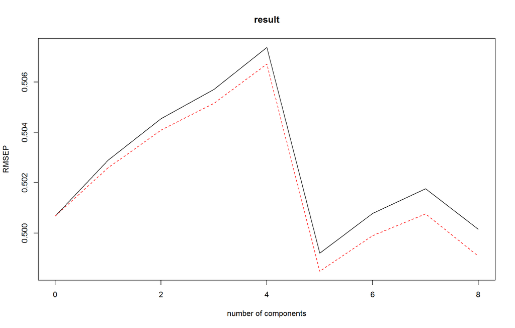

```r
validationplot(pcr_all_fit_full, val.type = "RMSEP")
```

It looks like not using all components gives a better CV performance, Also, it looks ike most of the variance is explained by a small subset of the components. (Although components aren’t the same as the original predictors, one can reasonably infer that a low number of components corresponds to a low number of variables.) I’ll ignore this for now and go ahead and use all predictors to make predictions and provide an estimate of the model’s test error rate (or, conversely, its test accuracy rate).

```r
pcr_all_prob_full <- predict(pcr_all_fit_full,
                             type = "response",
                             ncomp = length(names_x_all))
pcr_all_pred_full <- rep(0, dim(d_model)[1])
pcr_all_pred_full[pcr_all_prob_full > mean(pcr_all_prob_full)] = 1
table(pcr_all_pred_full, d_model$result)
```

```
##
## pcr_all_pred_full  0  1
##                 0 76 38
##                 1 53 73
```

```r
round(mean(pcr_all_pred_full == d_model$result), 2)
```

```
## [1] 0.62
```

It looks like this method generated a relatively good test accuracy rate. However, let’s not forget that this estimate of error is an underestimate because the model was trained and tested on the same data set. Thus, it is better to think of this test accuracy rate as the “theoretical” maximum test accuracy rate.

Nonetheless, this was a good exercise in dimensionality reduction. For the time being, I’ll skip consideration of partial least squares (PLS), which is another useful technique for dimensionality reduction.

#### Selecting the Variables

If I had to choose a “best” set of predictors given the information from this statistical approach combined with my own intuition, I would choose the `w_sportsbook_err1` and `prob_implied_combo` variables.

Regarding my choice of two variables instead of one or three or more, I think using a single variable is a bit too simplistic. On the other hand, using three or more predictors might create introduce more uncertainty (in a given model) than desired.

Now, because the previous outputs were fairly dense and may have been difficult to process, I’ll review the co-variances and residuals among only my choice of predictors in order to verify that they are independent of one another.

```r
names_x_select <- c("w_sportsbook_err1", "prob_implied_combo")
d_model_x_select <- d_model %>% dplyr::select(one_of(names_x_select))

d_cor_select <- round(cor(d_model_x_select), 2)
d_cor_select
```

```
##                    w_sportsbook_err1 prob_implied_combo
## w_sportsbook_err1               1.00              -0.04
## prob_implied_combo             -0.04               1.00
```

```r
# library(GGally)
# ggpairs(d_model_x_select, lower = list(combo = wrap("facethist", binwidth = 30)))
```

### Fitting the Selected Model

Alright, that’s enough of that. Now I’ll use my selected predictors to fit a logistic regression model.

```r
# glm() can work with either categorical or continuous response variable.
# However, family = binomial must be specified for a
# categorical response variable. Nevertheless, categorical variables may
# be coded as numerics and glm() will still function properly
# if family = binomial.
# glmnet(x, y, family = "binomial") is an alternative.
# Also, type = "response" should be specified in predict().
# If not, then another type (e.g. logit) may be used.
```

```r
fmla_select <- paste(name_y, paste(names_x_select, collapse = " + "), sep = " ~ ")
lr_select_fit_full <- glm(fmla_select, data = d_model, family = binomial)
summary(lr_select_fit_full)$coef
```

```
##                        Estimate Std. Error    z value    Pr(>|z|)
## (Intercept)        -0.229859971 0.13493963 -1.7034282 0.088487965
## w_sportsbook_err1  -0.008672729 0.01631812 -0.5314784 0.595087333
## prob_implied_combo  6.544361172 2.11158809  3.0992603 0.001940045
```

```r
coef(lr_select_fit_full)
```

```
##        (Intercept)  w_sportsbook_err1 prob_implied_combo
##       -0.229859971       -0.008672729        6.544361172
```

It looks like this model isn’t all too bad. However, even after my process of trying to identify the best predictors to use heuristically, the p-values indicate that only one of the predictors is signficant. This actually might not be a flaw in my selection process. It could just be that there isn’t a great combination of predictors out of those available. Anyways, I’ll disregard further formula experimentation for now.

```r
lr_select_prob_full <- predict(lr_select_fit_full, type = "response")
lr_select_pred_full <- rep(0, dim(d_model)[1])
# lr_select_pred_full[lr_select_prob_full > 0.5] = 1
lr_select_pred_full[lr_select_prob_full > mean(lr_select_prob_full)] = 1
table(lr_select_pred_full, d_model$result)
```

```
##
## lr_select_pred_full  0  1
##                   0 81 53
##                   1 48 58
```

```r
round(mean(lr_select_pred_full == d_model$result), 2)
```

```
## [1] 0.58
```

So it isn’t the worst model one could possibly come up with. At least it does better than 50% in predicting over/unders when trained and tested on the full data set. But this is more like a “theoretical” limit that underestimates the true test error because the model is trained and tested on the entire data set.

How much worse (or better) does the prediction performance get when properly trained and tested on different sets?

### Estimating Test Error

If I had a large number of observations and some set of data that I could refer to as true “test” set, then implementing a train-validate-test 3-step approach would be the next step. However, I don’t really have either, so the best that I can do is **estimate** the test set error of the model.

For this analysis, I’ll forego the creation of an explicit final “test” set and simply split the data set into train and test sets. The “test” set in this case is not a pure test set since it is used as part of the model refinement process. One might interpret it to be a “validation” set.

In this context, the test error estimate is the prediction error on the “test” set. [^12]

Splitting the data into train and test sets could be done in a number of ways, such as random sampling. However, I’m simply going to use a single year’s worth of data as a test set and the rest as the train set. I’ll do this for every year’s worth of data in the whole data set. This is essentially k-fold cross validation (CV). More specifically, because there are eight years in this data set, this is 8-fold CV.

```r
yrs_cv <- 2009:2016
lr_select_accuracy_pct <- list()
for (i in 1:length(yrs_cv)) {
  vector_train <- !(d_model$yr_start %in% yrs_cv[i])

  d_model_test <- d_model[!vector_train,]
  d_y_test <- d_model$result[!vector_train]
  d_model_train <- d_model[vector_train,]
  lr_select_fit_train <-
    glm(fmla_select, data = d_model_train, family = binomial)
  lr_select_prob_test <-
    predict(lr_select_fit_train, d_model_test, type = "response")
  lr_select_pred_test <- rep(0, dim(d_model_test)[1])
  lr_select_pred_test[lr_select_prob_test > mean(lr_select_prob_test)] = 1
  lr_select_accuracy_pct[i] <- mean(lr_select_pred_test == d_y_test)
  lr_select_conf_matrix <- table(lr_select_pred_test, d_y_test)
  if (i > 1) {
    lr_select_conf_matrix_df <-
      data.frame(
        rbind(lr_select_conf_matrix_df,
              cbind(
                data.frame(yr_start = rep(yrs_cv[i],
                                          length(lr_select_conf_matrix))),
                lr_select_conf_matrix
              )))
  } else {
    lr_select_conf_matrix_df <-
      data.frame(
        cbind(data.frame(yr_start = rep(yrs_cv[i], length(lr_select_conf_matrix)
        )),
        lr_select_conf_matrix))
  }
}
```

I can look at the total accuracy percent aggregagated over each fold in this 8-fold CV, as well as the accuracy percent for each individual fold.

```r
round(mean(as.numeric(lr_select_accuracy_pct)), 2)
```

```
## [1] 0.57
```

```r
round(as.numeric(lr_select_accuracy_pct), 2)
```

```
## [1] 0.50 0.50 0.63 0.87 0.63 0.43 0.47 0.57
```

I’ll go ahead and save the confusion matrix for each fold in the manual CV to compare the results with those for other models.

```r
lr_select_conf_matrix_tbl <- lr_select_conf_matrix_df %>%
  tbl_df() %>%
  rename(pred_cv = lr_select_pred_test, count = Freq) %>%
  mutate(model = "lr")
# lr_select_conf_matrix_tbl
```

As an alternative to this “manual” CV approach, I can use the `cv.glm` function in the `boot` package to perform cross validation. It performs k-fold cross validation with a default value of k = n, where n = # of observations. This is also known as leave-one-out-cross-validation (LOOCV).

```r
library(boot)
# Setting the seed to create reproducible results.
set.seed(42)
lr_select_cv_loocv <- cv.glm(data = d_model, glmfit = lr_select_fit_full)
round(1 - sqrt(lr_select_cv_loocv$delta[1]), 2)
```

```
## [1] 0.51
```

Now I’ll do a k-fold cross-fold validation with k =- 10.

```r
set.seed(42)
lr_select_cv_k10 <- cv.glm(data = d_model, glmfit = lr_select_fit_full, K = 10)
round(1 - sqrt(lr_select_cv_k10$delta[1]), 2)
```

```
## [1] 0.5
```

These estimates of test set error around 50% seem about right (unfortunately). The test accuracy rate generated by my manual k-fold cross-validation was a bit higher, but the results from the `cv.glm` calls indicate that it may underestimate the test error rate (although the error rates generated by the `cv.glm` calls are also estimates).

Perhaps a logistic regression model isn’t the best choice of model for this data set. Or, perhaps, a logistic regression model utilizing higher order terms and/or interaction terms would do better. However, I’ll end the exploration of regression classification models here and move on to something different.

## Linear Discriminant Analysis (LDA)

Now I’m going to try a linear discriminant analysis (LDA) model framework.

### Variable Selection

As I did in the variable selection process for my logisitic regression model, I’ll start by evaluating a model incorporating all predictors fit on the entire data set simply to help identify the most significant variables. Nevertheless, we should not forget that any predictions made by this model would provide an understimate of the true test error of the data.

```r
library(MASS)
# Need as.formula() for lda() function.
# Response variable may be either categorical or continutuous. Categorical
# variable may be coded as numerics and lda() output will be the same
# as if they were coded as factors.
lda_all_fit_full <- lda(as.formula(fmla_all), data = d_model)
lda_all_fit_full
```

```
## Call:
## lda(as.formula(fmla_all), data = d_model)
##
## Prior probabilities of groups:
##      0      1
## 0.5375 0.4625
##
## Group means:
##     w_lag1   w_diff2 result_lag1 w_sportsbook_err1 prob_implied_combo
## 0 40.57364  1.201550   0.4961240        0.02325581        -0.00166501
## 1 39.32432 -1.396396   0.4234234       -0.66216216         0.02569904
##   underdog_combo avg_scoring_margin_lag1 win_pct_close_games_lag1
## 0      0.6356589            -0.009302326                0.4900775
## 1      0.8018018            -0.013513514                0.5109459
##
## Coefficients of linear discriminants:
##                                   LD1
## w_lag1                   -0.002292630
## w_diff2                  -0.050226609
## result_lag1              -0.835403201
## w_sportsbook_err1         0.072071687
## prob_implied_combo        8.759630721
## underdog_combo            0.794534818
## avg_scoring_margin_lag1   0.003436002
## win_pct_close_games_lag1  2.265266958
```

```r
lda_all_pred_full <- predict(lda_all_fit_full, d_model)
lda_all_conf_matrix <- table(lda_all_pred_full$class, d_model$result)
lda_all_conf_matrix
```

```
##
##      0  1
##   0 90 55
##   1 39 56
```

```r
# The line below doesn't work.
# mean((lda_all_pred_full$posterior == d_model$result), na.rm = TRUE)
round(sum(sum(diag(lda_all_conf_matrix)) / sum(lda_all_conf_matrix)), 2)
```

```
## [1] 0.61
```

### Estimating Test Error

I’ll use the same manual CV method that I used with the logisitic regression model.

```r
lda_select_accuracy_pct <- list()
for (i in 1:length(yrs_cv)) {
  vector_train <- !(d_model$yr_start %in% yrs_cv[i])
  d_model_test <- d_model[!vector_train,]
  d_y_test <- d_model$result[!vector_train]
  lda_select_fit_train <-
    lda(as.formula(fmla_select), data = d_model, subset = vector_train)
  lda_select_pred_test <- predict(lda_select_fit_train, d_model_test)
  lda_select_conf_matrix <- table(lda_select_pred_test$class, d_y_test)
  lda_select_accuracy_pct[i] <-
    (sum(diag(lda_select_conf_matrix)) / sum(lda_select_conf_matrix))
  if (i > 1) {
    lda_select_conf_matrix_df <-
      data.frame(
        rbind(lda_select_conf_matrix_df,
              cbind(
                data.frame(yr_start = rep(yrs_cv[i], length(lda_select_conf_matrix))),
                lda_select_conf_matrix
              )))
  } else {
    lda_select_conf_matrix_df <-
      data.frame(
        cbind(data.frame(yr_start = rep(yrs_cv[i], length(lda_select_conf_matrix)
        )),
    lda_select_conf_matrix))
  }
}

lda_select_accuracy_pct <- unlist(lda_select_accuracy_pct)
round(mean(as.numeric(lda_select_accuracy_pct), na.rm = TRUE), 2)
```

```
## [1] 0.6
```

```r
round(as.numeric(lda_select_accuracy_pct), 2)
```

```
## [1] 0.50 0.60 0.53 0.80 0.67 0.60 0.47 0.60
```

```r
lda_select_conf_matrix_tbl <- lda_select_conf_matrix_df %>%
  tbl_df() %>%
  rename(pred_cv = Var1, count = Freq) %>%
  mutate(model = "lda")
# lda_select_conf_matrix_tbl
```

Not too bad … Maybe this is an acceptable model.

Now, becuase this model seemed to perform relatively well when properly trained and tested, I want to take a closer look at the train/test output of this LDA model. I’ll use the data from the 2016 season as a “pure” tet set and the data from the years prior to it as the train set. (In other words, I’m taking a closer look at the last iteration from the manual cross-validation method.)

```r
vector_train <- d_model$yr_start %in% yrs_cv[1:(length(yrs_cv) - 1)]
vector_test <- d_model$yr_start %in% yrs_cv[length(yrs_cv)]
# d_model_test <- d_model[!vector_train,]
# d_y_test <- d_model$result[!vector_train]
d_model_test <- d_model[vector_test,]
d_y_test <- d_model$result[vector_test]
lda_select_1yr_fit_train <- lda(as.formula(fmla_select), data = d_model, subset = vector_train)
lda_select_1yr_fit_train
```

```
## Call:
## lda(as.formula(fmla_select), data = d_model, subset = vector_train)
##
## Prior probabilities of groups:
##         0         1
## 0.5428571 0.4571429
##
## Group means:
##   w_sportsbook_err1 prob_implied_combo
## 0       -0.04385965       -0.002585566
## 1       -0.44791667        0.024761034
##
## Coefficients of linear discriminants:
##                           LD1
## w_sportsbook_err1  -0.0189921
## prob_implied_combo 16.4219169
```

Interestingly, it seems that this this model (incorporating only my chosen predictors) gives heavy weighting to the `prob_implied_combo` variable. The same is true of the LDA model incorporating all possible predictors (as well as the logisitc regression models).

```r
lda_select_1yr_pred_test <- predict(lda_select_1yr_fit_train, d_model_test)
lda_select_1yr_conf_matrix <- table(lda_select_1yr_pred_test$class, d_y_test)
lda_select_1yr_conf_matrix
```

```
##    d_y_test
##      0  1
##   0 10  7
##   1  5  8
```

```r
lda_select_1yr_pred_test$posterior[1:30, 1]
```

```
##         1         2         3         4         5         6         7
## 0.7133918 0.7204336 0.3853238 0.6725067 0.2845200 0.5228103 0.7256450
##         8         9        10        11        12        13        14
## 0.4493432 0.7290855 0.5924880 0.2723220 0.3698833 0.6758961 0.4968018
##        15        16        17        18        19        20        21
## 0.6281671 0.5249740 0.3118947 0.2502417 0.4892130 0.3043375 0.3250734
##        22        23        24        25        26        27        28
## 0.6834505 0.3420517 0.5769400 0.6753661 0.5152310 0.8302646 0.5422435
##        29        30
## 0.4736536 0.6739929
```

```r
sum(lda_select_1yr_pred_test$posterior[, 1] > 0.6)
```

```
## [1] 11
```

```r
sum(lda_select_1yr_pred_test$posterior[, 1] < 0.4)
```

```
## [1] 9
```

This model generates some fairly exaggerated probabilities. A more conservative model might exhbit all posterior probabilities around 0.5.

Which teams does this model project have the highest probability of outperforming/underperforming their expectations (as determined by the sportsbook win total)?

```r
# Need to re-introduce team data since it is not in d_model.
# Team column was removed from d_join when creating d_model.
g_teams <- d_win_totals_raw %>%
  filter(yr_start == 2016) %>%
  dplyr::select(team) %>%
  distinct() %>%
  arrange(sort(team)) %>%
  unlist()

max(lda_select_1yr_pred_test$posterior[, 1])
```

```
## [1] 0.8302646
```

```r
# This assumes that the teams are listed in alphabetical order in d_model.
# d_model_test$team[which.max(lda_select_1yr_pred_test$posterior[, 1])]
g_teams[which.max(lda_select_1yr_pred_test$posterior[, 1])]
```

```
## team27
##     SA
## 30 Levels: ATL BKN BOS CHA CHI CLE DAL DEN DET GS HOU IND LAC LAL ... WSH
```

```r
min(lda_select_1yr_pred_test$posterior[, 1])
```

```
## [1] 0.2502417
```

```r
g_teams[which.min(lda_select_1yr_pred_test$posterior[, 1])]
```

```
## team18
##    MIN
## 30 Levels: ATL BKN BOS CHA CHI CLE DAL DEN DET GS HOU IND LAC LAL ... WSH
```

One might say that the teams with the the lowest and highest posterior probabilites are the teams that the LDA model predicts have the greatest likelihood of going over and under respectively. [^13]

I’ll leave exploration of Quadratic Discriminant Analysis (QDA) models for another time. For now, I’ll move on to a different family of models.

## Decision Tree

Many people have heard of decision trees. They can be very useful for variable selection and can often produce simple, yet profound models.

### Variable Selection

Speaking of variable selection, I’ll do that now. I’ll do as I have been doing and fit a model using all predictors on the entire data set.

```r
library(tree)
set.seed(42)
tree_all_fit_full <- tree(fmla_all, data = d_model)
summary(tree_all_fit_full)
```

```
##
## Classification tree:
## tree(formula = fmla_all, data = d_model)
## Variables actually used in tree construction:
## [1] "prob_implied_combo"       "win_pct_close_games_lag1"
## [3] "avg_scoring_margin_lag1"  "w_sportsbook_err1"
## [5] "w_lag1"                   "underdog_combo"
## [7] "w_diff2"
## Number of terminal nodes:  25
## Residual mean deviance:  0.8224 = 176.8 / 215
## Misclassification error rate: 0.1833 = 44 / 240
```

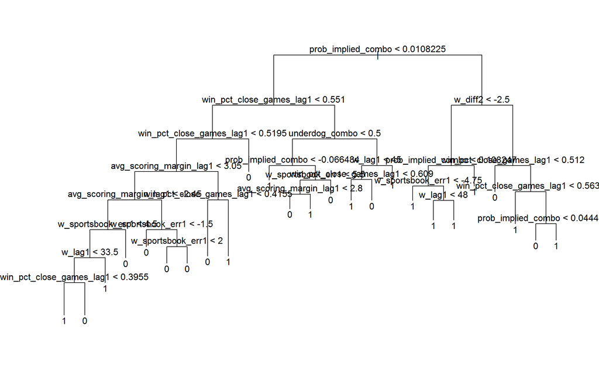

```r
# names(tree_all_fit_full)

plot(tree_all_fit_full)
text(tree_all_fit_full, pretty = 0)
```

An extension of the tree family of models is the random forest. This kind of model can reduce the amount of variance associated with traditional decision trees. Bagging and boosting also can use tree as building blocks, but I’ll stop short of looking at those models for the time being.

```r
library(randomForest)
set.seed(42)
rf_all_fit_full <-
  randomForest(
    as.formula(fmla_all),
    mtry = length(names_x_all),
    data = d_model,
    importance = TRUE
  )
rf_all_fit_full
```

```
##
## Call:
##  randomForest(formula = as.formula(fmla_all), data = d_model,      mtry = length(names_x_all), importance = TRUE)
##                Type of random forest: classification
##                      Number of trees: 500
## No. of variables tried at each split: 8
##
##         OOB estimate of  error rate: 40.42%
## Confusion matrix:
##    0  1 class.error
## 0 84 45   0.3488372
## 1 52 59   0.4684685
```

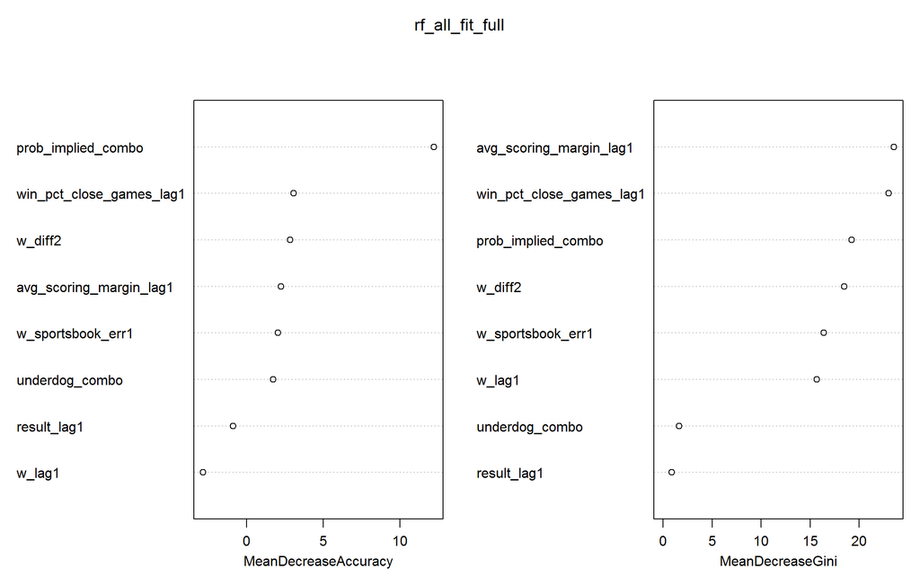

```r
# importance(rf_all_fit_full)
varImpPlot(rf_all_fit_full)
```

It looks like the random forest model identifies one of my select variables `prob_implied_combo` as having high importance. This was evident in the other types of models as well.

### Estimating Test Error

Now, I’ll create a decision tree model using only the same select variables that I’ve been using. The random forest model affirmed that they are (somewhat) significant relative to the other variables.

```r
set.seed(42)
library(tree)
set.seed(42)
tree_select_fit_full <- tree(fmla_select, data = d_model)
summary(tree_select_fit_full)
```

```
##
## Classification tree:
## tree(formula = fmla_select, data = d_model)
## Number of terminal nodes:  9
## Residual mean deviance:  1.224 = 282.7 / 231
## Misclassification error rate: 0.3375 = 81 / 240
```

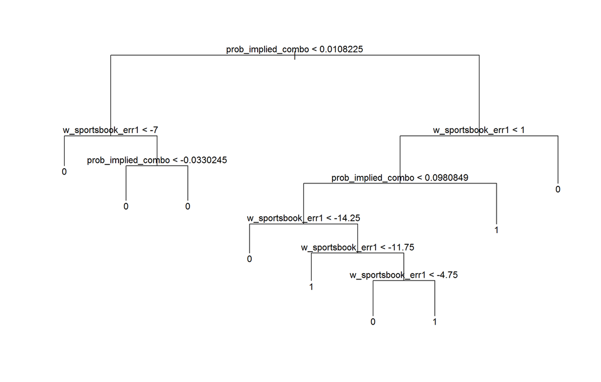

```r
# names(tree_select_fit_full)

plot(tree_select_fit_full)
text(tree_select_fit_full, pretty = 0)
```

Now, even though the `randomForest` function provides an estimate of error rate, I’ll be consistent with what I’ve done before and implement a manual k-fold CV for my tree model.

```r
tree_select_accuracy_pct <- list()
for (i in 1:length(yrs_cv)) {
  vector_train_seq <- seq(1, dim(d_model)[1])
  vector_train_seq <- vector_train_seq[-((((i - 1) * 30) + 1):(i * 30))]
  d_model_test <- d_model[-vector_train_seq,]
  d_y_test <- d_model$result[-vector_train_seq]
  d_model_train <- d_model[vector_train_seq,]
  tree_select_train <- tree(fmla_select, d_model_train)
  tree_select_pred_test <- predict(tree_select_train, d_model_test, type = "class")
  tree_select_conf_matrix <- table(tree_select_pred_test, d_y_test)
  tree_select_accuracy_pct[i] <- mean(tree_select_pred_test == d_y_test)
  if (i > 1) {
    tree_select_conf_matrix_df <-
      data.frame(
        rbind(tree_select_conf_matrix_df,
              cbind(
                data.frame(yr_start = rep(yrs_cv[i],
                                          length(tree_select_conf_matrix))),
                tree_select_conf_matrix
              )))
  } else {
    tree_select_conf_matrix_df <-
      data.frame(
        cbind(data.frame(yr_start = rep(yrs_cv[i], length(tree_select_conf_matrix)
        )),
        tree_select_conf_matrix))
  }
}

round(mean(as.numeric(tree_select_accuracy_pct), na.rm = TRUE), 2)
```

```
## [1] 0.6
```

```r
round(as.numeric(tree_select_accuracy_pct), 2)
```

```
## [1] 0.53 0.67 0.57 0.77 0.60 0.53 0.50 0.63
```

```r
tree_select_conf_matrix_tbl <- tree_select_conf_matrix_df %>%
  tbl_df() %>%
  rename(pred_cv = tree_select_pred_test, count = Freq) %>%
  mutate(model = "tree")
tree_select_conf_matrix_tbl
```

```
## # A tibble: 32 x 5
##    yr_start pred_cv d_y_test count model
##       <int>  <fctr>   <fctr> <int> <chr>
##  1     2009       0        0    12  tree
##  2     2009       1        0     4  tree
##  3     2009       0        1    10  tree
##  4     2009       1        1     4  tree
##  5     2010       0        0    15  tree
##  6     2010       1        0     2  tree
##  7     2010       0        1     8  tree
##  8     2010       1        1     5  tree
##  9     2011       0        0    12  tree
## 10     2011       1        0     3  tree
## # ... with 22 more rows
```

Thus, I now have an manual 8-fold CV estimate of test error for a tree model. There is a `cv.tree` function that I could use, but I’m fine with just using the results of my manual CV for now since I have used this same method of validation for the other models. I woud like to be as consistent as possible so that I can make some comparisons across models.

## Support Vector Machine (SVM)

Even though constructing a model that not only has low estimated test error is my primary goal, a model that is interpretable is also an important factor. Unfortunately, this is not one of the strengths of the next family of models that I’ll look at: support vector machines (SVM). While SVMs can be very useful for predicting categorical response variables and have many applications, the results of a fitted SVM model can be difficult to interpret. In particular, it is not advisable to use SVMs for variable selection. Nonetheless, for the sake of experimentation, I’ll see what I can do.

### Variable Selection

Similar to what I’ve done before, I’ll start by fitting a model including all possible predictors.

```r
library(e1071)

# Predictors can't be factors.
# Response variable must be numerics.
# Need as.formula().
# No default value for cost, so must specify one.
svm_all_fit_full <-
  svm(
    as.formula(fmla_all),
    data = d_model,
    kernel = "linear",
    cost = 0.1
  )
svm_all_fit_full
```

```
##
## Call:
## svm(formula = as.formula(fmla_all), data = d_model, kernel = "linear",
##     cost = 0.1)
##
##
## Parameters:
##    SVM-Type:  C-classification
##  SVM-Kernel:  linear
##        cost:  0.1
##       gamma:  0.125
##
## Number of Support Vectors:  209
```

```r
# Which points are SVMs?
# svm_all_fit_full$index
# plot() may not work since formula isn't explicit in svm() call.
# plot(svm_all_fit_full, d_model)
```

That was easy enough, although I’m not sure how much I can infer from the results. Nevertheless, in following my plan of action with other models, I’ll move on to training and testing.

This package has a `tune` function to perform k-fold cross validation (the default number of folds is 10.), which is useful for identifying good values for parameters such as `cost`. I arbitraryily used 0.1 before. Let’s see if that value is identified as a good value here.

```r
set.seed(42)
range_cost <- 10 ^ seq(-3, 2, 1)
svm_all_tune <-
  tune(
    svm,
    as.formula(fmla_all),
    data = d_model,
    kernel = "linear",
    ranges = list(cost = range_cost)
  )
summary(svm_all_tune)
```

```
##
## Parameter tuning of 'svm':
##
## - sampling method: 10-fold cross validation
##
## - best parameters:
##  cost
##   0.1
##
## - best performance: 0.4083333
##
## - Detailed performance results:
##    cost     error dispersion
## 1 1e-03 0.4625000 0.11858541
## 2 1e-02 0.4541667 0.09306592
## 3 1e-01 0.4083333 0.10356307
## 4 1e+00 0.4083333 0.11249143
## 5 1e+01 0.4125000 0.10290908
## 6 1e+02 0.4166667 0.10577463
```

It turns out that the best cost value from the several that I tried out is 0.1.

### Estimating Test Error

Now, to be consistent with some of the other model building that I’ve done, I’ll fit a model only incorporating my select predictors. Even though it is difficult to judge the parameters of a fitted SVM model in isolation, at least I will be able to compare the test error estimate of an SVM model here with the error exhibited by other models using only the same predictors. I’m not sure that this exactly qualifies as one-to-one comparison, but I think it’s a useful exercise.

First, I’ll find the optimal cost value for a model using only my select variables with the `tune` function.

```r
set.seed(42)
range_cost <- 10 ^ seq(-3, 2, 1)
svm_select_tune <-
  tune(
    svm,
    as.formula(fmla_select),
    data = d_model,
    kernel = "linear",
    ranges = list(cost = range_cost)
  )
summary(svm_select_tune)
```

```
##
## Parameter tuning of 'svm':
##
## - sampling method: 10-fold cross validation
##
## - best parameters:
##  cost
##   0.1
##
## - best performance: 0.4166667
##
## - Detailed performance results:
##    cost     error dispersion
## 1 1e-03 0.4625000 0.11858541
## 2 1e-02 0.4500000 0.13721210
## 3 1e-01 0.4166667 0.12108053
## 4 1e+00 0.4208333 0.09908922
## 5 1e+01 0.4166667 0.10015420
## 6 1e+02 0.4166667 0.10015420
```

```r
svm_select_best <- svm_select_tune$best.model
```

Now I’ll perform manual k-fold cross validation as I’ve done before.

```r
svm_select_accuracy_pct <- list()
for (i in 1:length(yrs_cv)) {
  vector_train <- !(d_model$yr_start %in% yrs_cv[i])
  d_model_test <- d_model[!vector_train,]
  d_y_test <- d_model$result[!vector_train]
  svm_select_pred_test <- predict(svm_select_best, newdata = d_model_test)
  svm_select_conf_matrix <- table(svm_select_pred_test, d_y_test)
  svm_select_accuracy_pct[i] <- mean(svm_select_pred_test == d_y_test)
  if (i > 1) {
    svm_select_conf_matrix_df <-
      data.frame(rbind(
        svm_select_conf_matrix_df,
        cbind(data.frame(yr_start = rep(
          yrs_cv[i], length(svm_select_conf_matrix)
        )),
        svm_select_conf_matrix)
      ))
  } else {
    svm_select_conf_matrix_df <-
      data.frame(cbind(data.frame(yr_start = rep(
        yrs_cv[i], length(svm_select_conf_matrix)
      )),
      svm_select_conf_matrix))
  }
}

round(mean(as.numeric(svm_select_accuracy_pct), na.rm = TRUE), 2)
```

```
## [1] 0.6
```

```r
round(as.numeric(svm_select_accuracy_pct), 2)
```

```
## [1] 0.57 0.57 0.50 0.83 0.70 0.53 0.53 0.60
```

```r
svm_select_conf_matrix_tbl <- svm_select_conf_matrix_df %>%
  tbl_df %>%
  rename(pred_cv = svm_select_pred_test, count = Freq) %>%
  mutate(model = "svm")
# svm_select_conf_matrix_tbl
```

It looks like this model is pretty good. However, that doesn’t change the fact that it’s difficult to interpret, so it might not be the best for my purposes.

# Conclusion

To conclude, I’ll quickly compare the exact predictions made by each model on the last year in the data set.

```r
d_y_test_1yr_compare <-
  data.frame(
    lr_select_pred_test,
    lda_select_pred_test$class,
    tree_select_pred_test,
    svm_select_pred_test
    )
d_y_test_1yr_compare
```

[output not shown]

I’d like to also compare the confusion matrices for the manual CV that I performed for all the models.

```r
d_conf_matrix_compare <-
  bind_rows(
    lr_select_conf_matrix_tbl,
    lda_select_conf_matrix_tbl,
    tree_select_conf_matrix_tbl,
    svm_select_conf_matrix_tbl
  )

d_conf_matrix_compare
```

[output not shown]

## Work to Do

I have a couple of ideas for what further exploration/experimentation could be done.

- I would like to try to incporate more team statistical data, such as offensive/defensive efficiency, etc. (Of course, I could only use lagged versions of these statistics for use in predicting outcomes.) Additionally, I think some other “non-traditional” statistical data could be useful, including variables indicating the change in team salary from one year to another, the change in mean/medain team age, the amount of injury “luck” the team had in the previous year, etc.

Nevertheless, even with more data and better models, I think there is probably a feasible limit on the accuracy of projecting team win totals around 60%. Sports like basketball are just too random to be able to predict extremely accurately.

- I want to include my own pick data and see if I can ascerntain any kind of patters in my picking behavior or identify some kind of personal bias. This kind of information could be used to help me either make better picks directly or create a model that recognizes my tendencies and “fades” my own picks in an optimal manner.

That’s all the analysis that I’m going to do on this subject for now.